# Unihan Data for Precedence Schemes

Alan Engel

27 September, 2024

```r
library(rlang)
library(tidyverse)
library(dplyr)
library(xml2)
library(tibble)
library(stringi)
library(magrittr)
library(igraph)
```

## Unihan data

Precedence schemes for selecting ideographs from groups or clusters may enter into normalization at several points. For example, the CITPC algorithm for determined replacement candidates for MJ characters ((情報処理推進機構 2015)) specifies that when there are two or more koseki candidates (see CITPC Moji Variants), precedence goes to Joyo Kanji, then to Jinmeiyo Kanji, and finally to JIS order. This vignette describes the extraction of propery data from the [Unicode Character Database](https://www.unicode.org/versions/Unicode15.1.0/) for the purpose of constructing various precedence schemes.

The desired properties are selected from the [Unicode Han Database](https://www.unicode.org/reports/tr38/tr38-35.html). Developers may find an [example from the Unicode utilities site](https://util.unicode.org/UnicodeJsps/character.jsp?a=4E9D) easier to follow. This script uses the [XML Representation of Unicode 15.1.0 UCD flat file (downloadable zip file)](https://www.unicode.org/Public/15.1.0/ucdxml/ucd.unihan.flat.zip).

- kFrequency is a rough frequency measurement of the ideograph’s occurance in a collection of traditional USENET posting. It may be useful for selecting among traditional Chinese ideographs.
- kTotalStrokes is the total number of strokes in the ideograph and can be used for selection based on simplicity.
- kIICore and kUnihanCore2020 specify the ideograph’s membership in IRG-produced minimal sets of required ideographs for East Asian use. It may be used to select based on use in, for example, the PRC, Japan or Taiwan.
- kJoyoKanji and kJinmeiyoKanji designate membership in standardized Japanese collections.
- kJis0, kJis1 and kJIS0213 designate membership in standardized Japanese collections.

```r
zippath <- file.path(project_extdata_path(),"ucd","ucd.unihan.flat.zip")
t <- tempdir()
unzip(zippath,exdir=t)
xml <- xml2::read_xml(file.path(t,"ucd.unihan.flat.xml"))
ns <- xml_ns_rename(xml_ns(xml), d1 = "u")
charelements <- xml_find_all(xml, "/u:ucd/u:repertoire/u:char", ns)
as.POSIXlt(Sys.time())
```

```
## [1] "2024-09-27 13:17:02 JST"
```

```r
dv <- lapply(charelements, function(charelement) {
  df <- suppressWarnings(tibble(
    ucs = as.hexmode(xml_attr(charelement, attr="cp", default = NA)),
    kFrequency = as.integer(xml_attr(charelement, attr="kFrequency", default = NA)),
    kTotalStrokes = as.integer(xml_attr(charelement, attr="kTotalStrokes", default = NA)),
    kIICore = xml_attr(charelement, attr="kIICore", default = ""),
    kUnihanCore2020 = xml_attr(charelement, attr="kUnihanCore2020", default = ""),
    kJinmeiyoKanji = xml_attr(charelement, attr="kJinmeiyoKanji", default = NA),
    kJis0 = xml_attr(charelement, attr="kJis0", default = NA),
    kJis1 = xml_attr(charelement, attr="kJis1", default = NA),
    kJIS0213 = xml_attr(charelement, attr="kJIS0213", default = NA),
    kJoyoKanji = xml_attr(charelement, attr="kJoyoKanji", default = NA),
    kMojiJoho = xml_attr(charelement, attr="kMojiJoho", default = NA),
  ), classes = "warning")
})
unihanPrecedenceData <- dplyr::bind_rows(dv)
as.POSIXlt(Sys.time())
```

```
## [1] "2024-09-27 13:22:28 JST"
```

The file ucd.unihan.flat.zip is missing kTotalStrokes data for 4 ideographs. These are manually added below using data from Moji Joho file mji.00602.xlsx.

```r
unihanPrecedenceData[which(unihanPrecedenceData$ucs == as.hexmode(0x08303)),]$kTotalStrokes <- 8
unihanPrecedenceData[which(unihanPrecedenceData$ucs == as.hexmode(0x09AA8)),]$kTotalStrokes <- 10
unihanPrecedenceData[which(unihanPrecedenceData$ucs == as.hexmode(0x2010E)),]$kTotalStrokes <- 2
unihanPrecedenceData[which(unihanPrecedenceData$ucs == as.hexmode(0x2A060)),]$kTotalStrokes <- 18
unihanPrecedenceData
```

```
## # A tibble: 98,682 × 11
##    ucs       kFrequency kTotalStrokes kIICore kUnihanCore2020 kJinmeiyoKanji kJis0 kJis1 kJIS0213 kJoyoKanji kMojiJoho
##    <hexmode>      <int>         <int> <chr>   <chr>           <chr>          <chr> <chr> <chr>    <chr>      <chr>
##  1 3400              NA             5 ""      ""              <NA>           <NA>  <NA>  <NA>     <NA>       MJ000004
##  2 3401              NA             6 ""      ""              <NA>           <NA>  <NA>  <NA>     <NA>       MJ000005
##  3 3402              NA             6 ""      ""              <NA>           <NA>  <NA>  1,14,03  <NA>       MJ000006
##  4 3403              NA             3 ""      ""              <NA>           <NA>  <NA>  <NA>     <NA>       <NA>
##  5 3404              NA             3 ""      ""              <NA>           <NA>  <NA>  <NA>     <NA>       MJ068055 MJ000008:E0100 MJ000007:E0101…
##  6 3405              NA             2 ""      ""              <NA>           <NA>  <NA>  <NA>     <NA>       MJ000009
##  7 3406              NA             6 ""      ""              <NA>           <NA>  <NA>  2,01,13  <NA>       MJ000010
##  8 3407              NA             3 ""      ""              <NA>           <NA>  <NA>  <NA>     <NA>       MJ067953
##  9 3408              NA             3 ""      ""              <NA>           <NA>  <NA>  <NA>     <NA>       MJ067954
## 10 3409              NA             3 ""      ""              <NA>           <NA>  <NA>  <NA>     <NA>       MJ067955
## # ℹ 98,672 more rows
```

## Precedence schemes

While normalization algorithms may be intended for background comparison of name authorities, it may be desirable to enable users or working groups to select a character regime in which they work comfortably. The precedence schemes described below select cluster representatives with preference for one of Japanese, simplified Chinese and traditional Chinese. They also provide preference for ideographs taught in lower grade levels.

### Using kUnihanCore2020 properties

The property kUnihanCore2020 is used for ideographs that are in the minimal set of ideographs required for East Asia. Ken Lunde (Lunde 2019) provides a detailed description and history of this property along with a [stand-alone data file](https://www.unicode.org/L2/L2019/19388-unihancore2020-data.txt). This property covers 20,652 CJK Unified Ideographs and 68 CJK Compatibility Ideographs, 10,910 more than the older kIICore property. From the kUnihanCore2020 ideographs, the scripts below cover Japan (6,490 ideographs having the ‘J’ tag), PRC (8,247 ideographs having the ‘G’ tag), and ROC (13,068 ideographs having the ‘T’ tag). A precedence value (jCoreRank, gCoreRank and tCoreRank) is 8 minus the number of source tags. The value 8 is assigned to all ideographs not in the respective core set. This provides for precedence favoring ideographs that more broadly used as reflected by the number of IRG source tags.

### Using grade levels

The educational administrations in China, Japan, Taiwan and Hong Kong specify the ideographs are to be taught at which grade levels in their school systems. The levels for Hong Kong are included in the [Unihan database](https://www.unicode.org/reports/tr38/tr38-35.html#N10106) as the property kGradeLevel. Those for China, Japan and Taiwan can be obtained from online sources and are included in this package as the following datasets:

| Authority | Dataset |
| --- | --- |
| China | zhXiaoxueWenzi |
| Japan | kyoikuKanji |
| Taiwan | twXiaoxueWenzi |

```r
kyoikuKanji <- DataPackageR::datapackager_object_read("kyoikuKanji")
jpPrecedence <-unihanPrecedenceData %>%
    mutate(jCoreRank = as.integer(ifelse(stri_detect_fixed(kUnihanCore2020,'J'), 8-stri_length(kUnihanCore2020), 8)),.after=ucs) %>%
    dplyr::left_join(kyoikuKanji, by=join_by(ucs == ucs)) %>%
    mutate(jpRank = as.integer(ifelse(!is.na(jpGrade), jpGrade,
                ifelse(!is.na(kJoyoKanji),7,
                ifelse(!is.na(kJinmeiyoKanji),8,9))))
                ,.after = jCoreRank ) %>%
    select(ucs,char,jCoreRank ,jpRank)
jpPrecedence
```

```
## # A tibble: 98,682 × 4
##    ucs       char  jCoreRank jpRank
##    <hexmode> <chr>     <int>  <int>
##  1 3400      <NA>          8      9
##  2 3401      <NA>          8      9
##  3 3402      <NA>          8      9
##  4 3403      <NA>          8      9
##  5 3404      <NA>          8      9
##  6 3405      <NA>          8      9
##  7 3406      <NA>          8      9
##  8 3407      <NA>          8      9
##  9 3408      <NA>          8      9
## 10 3409      <NA>          8      9
## # ℹ 98,672 more rows
```

```r
subset <- jpPrecedence %>% filter(jCoreRank < 8, jpRank < 9)
cc <-cor.test(subset$jCoreRank, subset$jpRank, method = "pearson")
stringi::stri_printf("Pearson correlation %.3f, CI %.3f-%.3f, p-value: %.2f",
                            round(cc$estimate,digits=2),round(cc$conf.int[1],digits=2),
                            round(cc$conf.int[2],digits=2),round(cc$p.value,digits=2))
```

```
## Pearson correlation 0.070, CI 0.030-0.110, p-value: 0.00
```

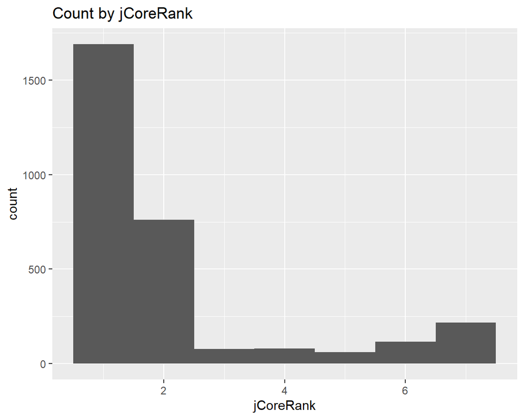

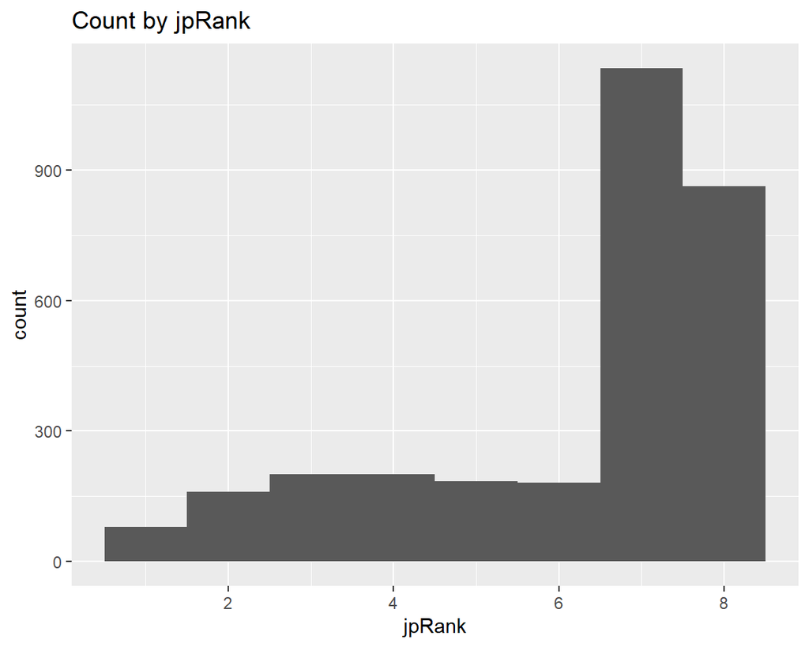

The PRC grade level ideograph lists cover the first 6 grades. The grade precedences (zhRank) below are set to the respective grade levels for these lists and 9 for all other ideographs.

```r
zhXiaoxueWenzi <- DataPackageR::datapackager_object_read("zhXiaoxueWenzi")
zhPrecedence <- unihanPrecedenceData %>%
    mutate(gCoreRank = as.integer(ifelse(stri_detect_fixed(kUnihanCore2020,'G'), 8-stri_length(kUnihanCore2020), 8)),.after=ucs) %>%
    dplyr::left_join(zhXiaoxueWenzi, by=join_by(ucs == ucs)) %>%
    mutate(zhRank = as.integer(ifelse(!is.na(zhGrade), zhGrade,9))
                ,.after = gCoreRank) %>%
    select(ucs,char,gCoreRank,zhRank )
zhPrecedence
```

```
## # A tibble: 98,703 × 4
##    ucs       char  gCoreRank zhRank
##    <hexmode> <chr>     <int>  <int>
##  1 3400      <NA>          8      9
##  2 3401      <NA>          8      9
##  3 3402      <NA>          8      9
##  4 3403      <NA>          8      9
##  5 3404      <NA>          8      9
##  6 3405      <NA>          8      9
##  7 3406      <NA>          8      9
##  8 3407      <NA>          8      9
##  9 3408      <NA>          8      9
## 10 3409      <NA>          8      9
## # ℹ 98,693 more rows
```

```r
zhsubset <- zhPrecedence %>% filter(gCoreRank < 8, zhRank < 9)
zhcc <-cor.test(zhsubset$gCoreRank, zhsubset$zhRank, method = "pearson")
stringi::stri_printf("Pearson correlation %.3f, CI %.3f-%.3f, p-value: %.2f",
                            round(zhcc$estimate,digits=2),round(zhcc$conf.int[1],digits=2),
                            round(zhcc$conf.int[2],digits=2),round(zhcc$p.value,digits=2))
```

```
## Pearson correlation 0.060, CI 0.010-0.100, p-value: 0.01
```

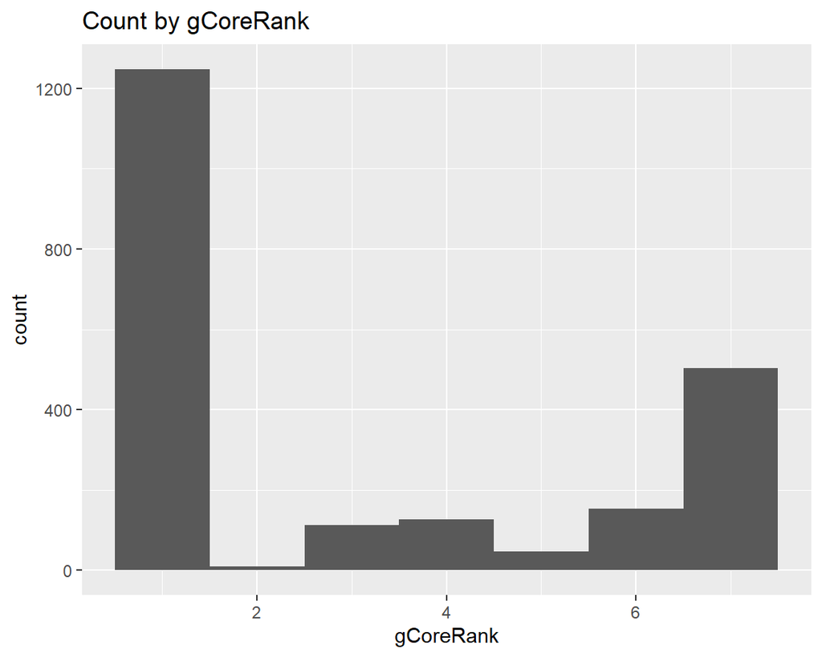

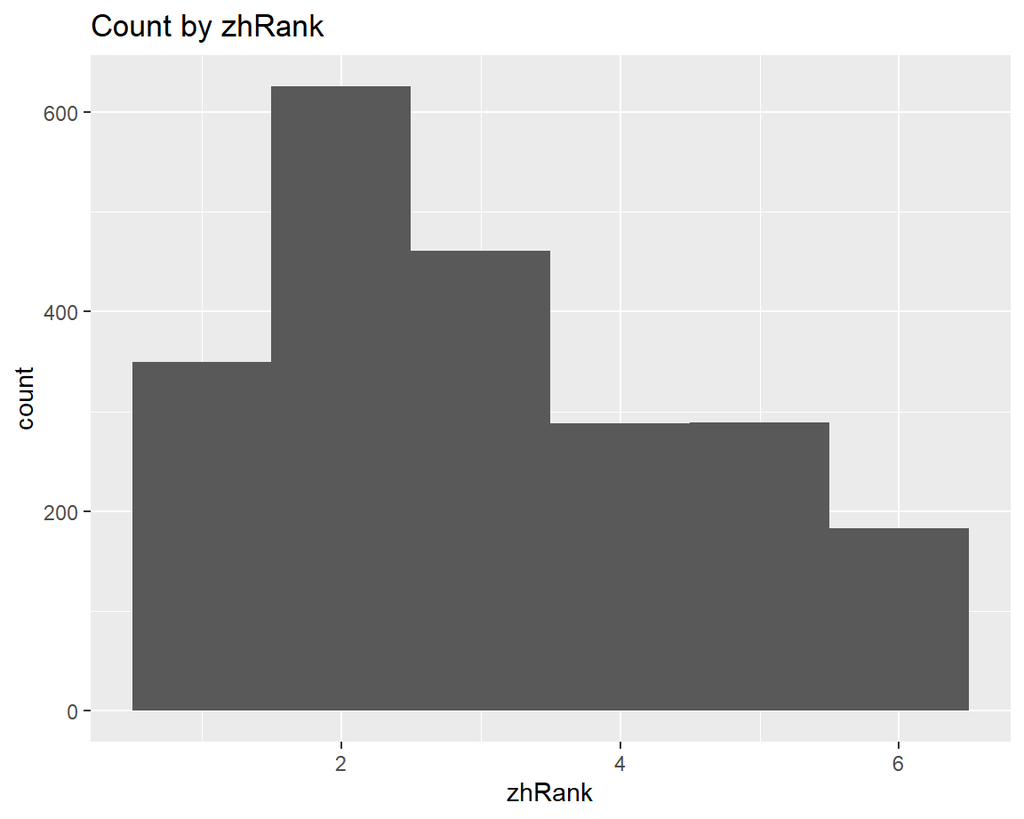

The Taiwan ideograph lists are for grades 1-9. The grade precedences (twRank) below are set to the grade level for grades 1-8 and 9 for all other ideographs. Restricting the maximum value to 9 allows twRank to be represented by a single digit in the next step.

```r
twXiaoxueWenzi <- DataPackageR::datapackager_object_read("twXiaoxueWenzi")
twPrecedence <- unihanPrecedenceData %>%
    mutate(tCoreRank = as.integer(ifelse(stri_detect_fixed(kUnihanCore2020,'T'), 8-stri_length(kUnihanCore2020), 8)),.after=ucs) %>%
    dplyr::left_join(twXiaoxueWenzi, by=join_by(ucs == ucs)) %>%
    mutate(twRank = as.integer(ifelse(!is.na(twGrade), twGrade,9))
                ,.after = tCoreRank) %>%
    select(ucs,char,tCoreRank,twRank)
twPrecedence
```

```
## # A tibble: 98,682 × 4
##    ucs       char  tCoreRank twRank
##    <hexmode> <chr>     <int>  <int>
##  1 3400      <NA>          8      9
##  2 3401      <NA>          8      9
##  3 3402      <NA>          8      9
##  4 3403      <NA>          8      9
##  5 3404      <NA>          8      9
##  6 3405      <NA>          8      9
##  7 3406      <NA>          8      9
##  8 3407      <NA>          8      9
##  9 3408      <NA>          8      9
## 10 3409      <NA>          8      9
## # ℹ 98,672 more rows
```

```r
twsubset <- twPrecedence %>% filter(tCoreRank < 8, twRank < 9)
zhcc <-cor.test(twsubset$tCoreRank, twsubset$twRank, method = "pearson")
stringi::stri_printf("Pearson correlation %.3f, CI %.3f-%.3f, p-value: %.2f",
                            round(zhcc$estimate,digits=2),round(zhcc$conf.int[1],digits=2),
                            round(zhcc$conf.int[2],digits=2),round(zhcc$p.value,digits=2))
```

```
## Pearson correlation 0.200, CI 0.160-0.230, p-value: 0.00
```

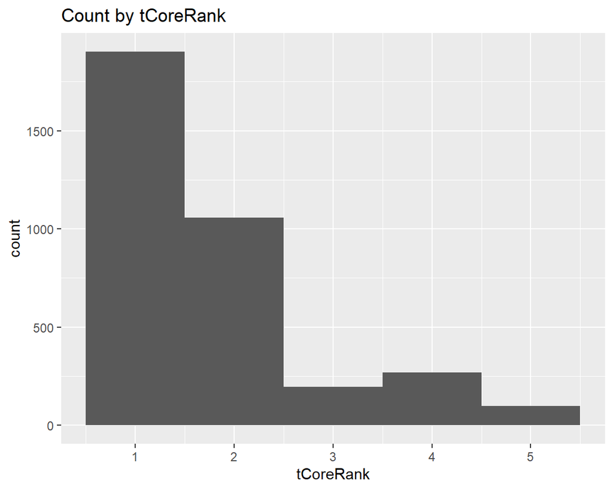

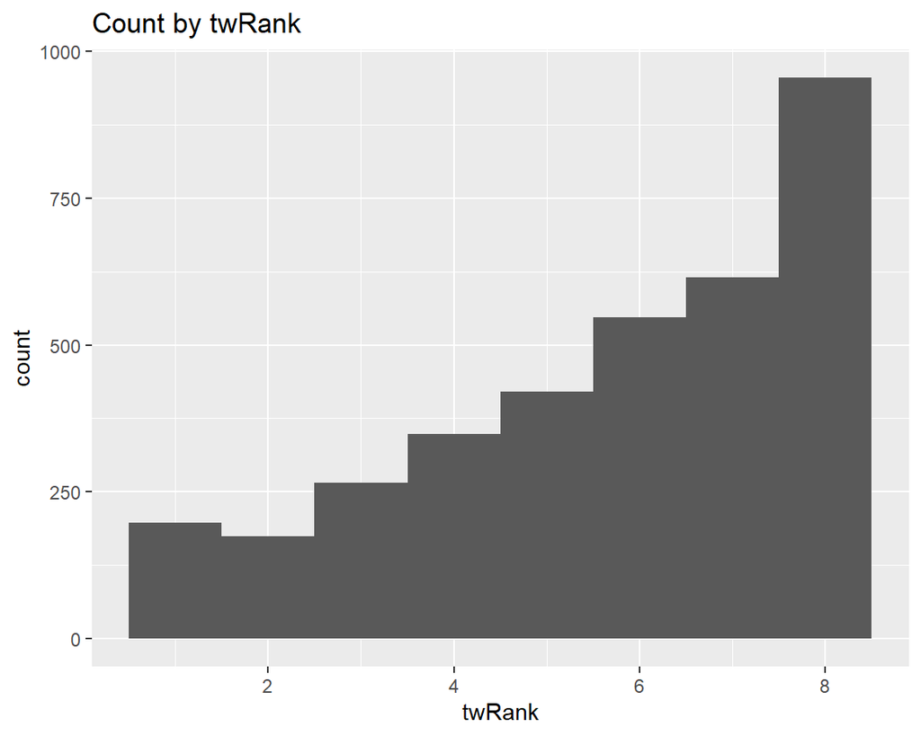

## Put it together

```r
jctPrecedence <- unihanPrecedenceData %>% select(ucs,kTotalStrokes) %>%
    dplyr::inner_join(select(jpPrecedence,ucs,jCoreRank,jpRank), by=join_by(ucs == ucs))  %>%
    dplyr::inner_join(select(zhPrecedence,ucs,gCoreRank,zhRank), by=join_by(ucs == ucs)) %>%
    dplyr::inner_join(select(twPrecedence,ucs,tCoreRank,twRank), by=join_by(ucs == ucs))
jctPrecedence
```

```
## # A tibble: 98,703 × 8
##    ucs       kTotalStrokes jCoreRank jpRank gCoreRank zhRank tCoreRank twRank
##    <hexmode>         <int>     <int>  <int>     <int>  <int>     <int>  <int>
##  1 3400                  5         8      9         8      9         8      9
##  2 3401                  6         8      9         8      9         8      9
##  3 3402                  6         8      9         8      9         8      9
##  4 3403                  3         8      9         8      9         8      9
##  5 3404                  3         8      9         8      9         8      9
##  6 3405                  2         8      9         8      9         8      9
##  7 3406                  6         8      9         8      9         8      9
##  8 3407                  3         8      9         8      9         8      9
##  9 3408                  3         8      9         8      9         8      9
## 10 3409                  3         8      9         8      9         8      9
## # ℹ 98,693 more rows
```

## Next task

Integrate mojiVariants with unihanVariants.

# References

Lunde, Ken. 2019. “New Unihan Database Property: kUnihanCore2020.” Unicode® Technical Committee. https://www.unicode.org/L2/L2019/19388-unihan-core-2020.pdf.

情報処理推進機構. 2015. “縮退マップについて.” September 25, 2015. https://moji.or.jp/wp-content/mojikiban/2015/09/20150925_5.pdf.